# Predict Bike Sharing Demand with AutoGluon Template

## Project: Predict Bike Sharing Demand with AutoGluon

This notebook is a template with each step that you need to complete for the project.

Please fill in your code where there are explicit `?` markers in the notebook. You are welcome to add more cells and code as you see fit.

Once you have completed all the code implementations, please export your notebook as a HTML file so the reviews can view your code. Make sure you have all outputs correctly outputted.

`File-> Export Notebook As... -> Export Notebook as HTML`

There is a writeup to complete as well after all code implememtation is done. Please answer all questions and attach the necessary tables and charts. You can complete the writeup in either markdown or PDF.

Completing the code template and writeup template will cover all of the rubric points for this project.

The rubric contains "Stand Out Suggestions" for enhancing the project beyond the minimum requirements. The stand out suggestions are optional. If you decide to pursue the "stand out suggestions", you can include the code in this notebook and also discuss the results in the writeup file.

## Step 1: Create an account with Kaggle

### Create Kaggle Account and download API key

Below is example of steps to get the API username and key. Each student will have their own username and key.

1. Open account settings.

2. Scroll down to API and click Create New API Token.

3. Open up `kaggle.json` and use the username and key.


## Step 2: Download the Kaggle dataset using the kaggle python library

### Open up Sagemaker Studio and use starter template

1. Notebook should be using a `ml.t3.medium` instance (2 vCPU + 4 GiB)
2. Notebook should be using kernal: `Python 3 (MXNet 1.8 Python 3.7 CPU Optimized)`

### Install packages

```python
!pip install -U pip
!pip install -U setuptools wheel
!pip install -U "mxnet<2.0.0" bokeh==2.0.1
!pip install autogluon --no-cache-dir
# Without --no-cache-dir, smaller aws instances may have trouble installing
```

[output not shown]

[output cut: 10 more lines]

[output not shown]

### Setup Kaggle API Key

```python
!pip install -q kaggle
```

```python
# create the .kaggle directory and an empty kaggle.json file
!mkdir -p /home/sagemaker-user/.kaggle
!touch /home/sagemaker-user/.kaggle/kaggle.json
!chmod 600 /home/sagemaker-user/.kaggle/kaggle.json
```

```python
# Fill in your user name and key from creating the kaggle account and API token file
import json
kaggle_username = "edgarmarg"
kaggle_key = "874722ccd3bea33d0677508d5e0fa08d"

# Save API token the kaggle.json file
with open("/home/sagemaker-user/.kaggle/kaggle.json", "w") as f:
    f.write(json.dumps({"username": kaggle_username, "key": kaggle_key}))
```

### Download and explore dataset

### Go to the [bike sharing demand competition](https://www.kaggle.com/c/bike-sharing-demand) and agree to the terms

```python
# Download the dataset, it will be in a .zip file so you'll need to unzip it as well.
!kaggle competitions download -c bike-sharing-demand
# If you already downloaded it you can use the -o command to overwrite the file
!unzip -o bike-sharing-demand.zip
```

```
Downloading bike-sharing-demand.zip to /home/sagemaker-user/nd009t-c1-intro-to-ml-project-starter
Archive:  bike-sharing-demand.zip
  inflating: sampleSubmission.csv
  inflating: test.csv
  inflating: train.csv
```

```python
import pandas as pd
from autogluon.tabular import TabularPredictor
```

```python
# Create the train dataset in pandas by reading the csv
# Set the parsing of the datetime column so you can use some of the `dt` features in pandas later
train = pd.DataFrame(pd.read_csv("train.csv"))
train['datetime'] = pd.to_datetime(train['datetime'])
train.head()
```

|  | datetime | season | holiday | workingday | weather | temp | atemp | humidity | windspeed | casual | registered | count |
| --- | --- | --- | --- | --- | --- | --- | --- | --- | --- | --- | --- | --- |
| 0 | 2011-01-01 00:00:00 | 1 | 0 | 0 | 1 | 9.84 | 14.395 | 81 | 0.0 | 3 | 13 | 16 |
| 1 | 2011-01-01 01:00:00 | 1 | 0 | 0 | 1 | 9.02 | 13.635 | 80 | 0.0 | 8 | 32 | 40 |
| 2 | 2011-01-01 02:00:00 | 1 | 0 | 0 | 1 | 9.02 | 13.635 | 80 | 0.0 | 5 | 27 | 32 |
| 3 | 2011-01-01 03:00:00 | 1 | 0 | 0 | 1 | 9.84 | 14.395 | 75 | 0.0 | 3 | 10 | 13 |
| 4 | 2011-01-01 04:00:00 | 1 | 0 | 0 | 1 | 9.84 | 14.395 | 75 | 0.0 | 0 | 1 | 1 |

```python
# Simple output of the train dataset to view some of the min/max/varition of the dataset features.
train.describe()
```

|  | datetime | season | holiday | workingday | weather | temp | atemp | humidity | windspeed | casual | registered | count |
| --- | --- | --- | --- | --- | --- | --- | --- | --- | --- | --- | --- | --- |
| count | 10886 | 10886.000000 | 10886.000000 | 10886.000000 | 10886.000000 | 10886.00000 | 10886.000000 | 10886.000000 | 10886.000000 | 10886.000000 | 10886.000000 | 10886.000000 |
| mean | 2011-12-27 05:56:22.399411968 | 2.506614 | 0.028569 | 0.680875 | 1.418427 | 20.23086 | 23.655084 | 61.886460 | 12.799395 | 36.021955 | 155.552177 | 191.574132 |
| min | 2011-01-01 00:00:00 | 1.000000 | 0.000000 | 0.000000 | 1.000000 | 0.82000 | 0.760000 | 0.000000 | 0.000000 | 0.000000 | 0.000000 | 1.000000 |
| 25% | 2011-07-02 07:15:00 | 2.000000 | 0.000000 | 0.000000 | 1.000000 | 13.94000 | 16.665000 | 47.000000 | 7.001500 | 4.000000 | 36.000000 | 42.000000 |
| 50% | 2012-01-01 20:30:00 | 3.000000 | 0.000000 | 1.000000 | 1.000000 | 20.50000 | 24.240000 | 62.000000 | 12.998000 | 17.000000 | 118.000000 | 145.000000 |
| 75% | 2012-07-01 12:45:00 | 4.000000 | 0.000000 | 1.000000 | 2.000000 | 26.24000 | 31.060000 | 77.000000 | 16.997900 | 49.000000 | 222.000000 | 284.000000 |
| max | 2012-12-19 23:00:00 | 4.000000 | 1.000000 | 1.000000 | 4.000000 | 41.00000 | 45.455000 | 100.000000 | 56.996900 | 367.000000 | 886.000000 | 977.000000 |
| std | NaN | 1.116174 | 0.166599 | 0.466159 | 0.633839 | 7.79159 | 8.474601 | 19.245033 | 8.164537 | 49.960477 | 151.039033 | 181.144454 |

```python
# Create the test pandas dataframe in pandas by reading the csv, remember to parse the datetime!
test = pd.DataFrame(pd.read_csv("test.csv"))
test['datetime'] = pd.to_datetime(test['datetime'])
test.head()
```

|  | datetime | season | holiday | workingday | weather | temp | atemp | humidity | windspeed |
| --- | --- | --- | --- | --- | --- | --- | --- | --- | --- |
| 0 | 2011-01-20 00:00:00 | 1 | 0 | 1 | 1 | 10.66 | 11.365 | 56 | 26.0027 |
| 1 | 2011-01-20 01:00:00 | 1 | 0 | 1 | 1 | 10.66 | 13.635 | 56 | 0.0000 |
| 2 | 2011-01-20 02:00:00 | 1 | 0 | 1 | 1 | 10.66 | 13.635 | 56 | 0.0000 |
| 3 | 2011-01-20 03:00:00 | 1 | 0 | 1 | 1 | 10.66 | 12.880 | 56 | 11.0014 |
| 4 | 2011-01-20 04:00:00 | 1 | 0 | 1 | 1 | 10.66 | 12.880 | 56 | 11.0014 |

```python
# Same thing as train and test dataset
submission = pd.DataFrame(pd.read_csv("sampleSubmission.csv"))
submission['datetime'] = pd.to_datetime(submission['datetime'])
submission.head()
```

|  | datetime | count |
| --- | --- | --- |
| 0 | 2011-01-20 00:00:00 | 0 |
| 1 | 2011-01-20 01:00:00 | 0 |
| 2 | 2011-01-20 02:00:00 | 0 |
| 3 | 2011-01-20 03:00:00 | 0 |
| 4 | 2011-01-20 04:00:00 | 0 |

## Step 3: Train a model using AutoGluon’s Tabular Prediction

Requirements:

- We are predicting `count`, so it is the label we are setting.
- Ignore `casual` and `registered` columns as they are also not present in the test dataset.
- Use the `root_mean_squared_error` as the metric to use for evaluation.
- Set a time limit of 10 minutes (600 seconds).
- Use the preset `best_quality` to focus on creating the best model.

```python
predictor = TabularPredictor(
    label='count',
    eval_metric='root_mean_squared_error',
    learner_kwargs={
        'ignored_columns': ['casual', 'registered'],
    }
).fit(
    train_data=train,
    time_limit=600,
    presets='best_quality',
)
```

```
No path specified. Models will be saved in: "AutogluonModels/ag-20240504_052238"
Presets specified: ['best_quality']
Stack configuration (auto_stack=True): num_stack_levels=1, num_bag_folds=8, num_bag_sets=20
Beginning AutoGluon training ... Time limit = 600s
AutoGluon will save models to "AutogluonModels/ag-20240504_052238"
AutoGluon Version:  0.8.2
Python Version:     3.10.14
Operating System:   Linux
Platform Machine:   x86_64
Platform Version:   #1 SMP Sat Mar 23 09:49:55 UTC 2024
Disk Space Avail:   20.97 GB / 21.46 GB (97.7%)
Train Data Rows:    10886
Train Data Columns: 11
Label Column: count
Preprocessing data ...
AutoGluon infers your prediction problem is: 'regression' (because dtype of label-column == int and many unique label-values observed).
	Label info (max, min, mean, stddev): (977, 1, 191.57413, 181.14445)
	If 'regression' is not the correct problem_type, please manually specify the problem_type parameter during predictor init (You may specify problem_type as one of: ['binary', 'multiclass', 'regression'])
Using Feature Generators to preprocess the data ...
Dropping user-specified ignored columns: ['casual', 'registered']
Fitting AutoMLPipelineFeatureGenerator...
	Available Memory:                    6243.51 MB
	Train Data (Original)  Memory Usage: 0.78 MB (0.0% of available memory)
	Inferring data type of each feature based on column values. Set feature_metadata_in to manually specify special dtypes of the features.
	Stage 1 Generators:
		Fitting AsTypeFeatureGenerator...
			Note: Converting 2 features to boolean dtype as they only contain 2 unique values.
	Stage 2 Generators:
		Fitting FillNaFeatureGenerator...
	Stage 3 Generators:
		Fitting IdentityFeatureGenerator...
		Fitting DatetimeFeatureGenerator...
	Stage 4 Generators:
		Fitting DropUniqueFeatureGenerator...
	Stage 5 Generators:
		Fitting DropDuplicatesFeatureGenerator...
	Types of features in original data (raw dtype, special dtypes):
		('datetime', []) : 1 | ['datetime']
		('float', [])    : 3 | ['temp', 'atemp', 'windspeed']
		('int', [])      : 5 | ['season', 'holiday', 'workingday', 'weather', 'humidity']
```

[output cut: 27 more lines]

[output not shown]

[output not shown]

```
	-131.4609	 = Validation score   (-root_mean_squared_error)
	36.62s	 = Training   runtime
	4.89s	 = Validation runtime
Fitting model: LightGBM_BAG_L1 ... Training model for up to 350.66s of the 550.73s of remaining time.
	Fitting 8 child models (S1F1 - S1F8) | Fitting with SequentialLocalFoldFittingStrategy
```

```
[1000]	valid_set's rmse: 130.818
[1000]	valid_set's rmse: 133.204
[1000]	valid_set's rmse: 130.928
[1000]	valid_set's rmse: 126.846
[1000]	valid_set's rmse: 131.426
[1000]	valid_set's rmse: 133.655
[1000]	valid_set's rmse: 132.155
[1000]	valid_set's rmse: 130.62
```

```
	-131.0542	 = Validation score   (-root_mean_squared_error)
	10.01s	 = Training   runtime
	1.02s	 = Validation runtime
Fitting model: RandomForestMSE_BAG_L1 ... Training model for up to 338.2s of the 538.27s of remaining time.
	-116.5484	 = Validation score   (-root_mean_squared_error)
	13.46s	 = Training   runtime
	0.53s	 = Validation runtime
Fitting model: CatBoost_BAG_L1 ... Training model for up to 323.74s of the 523.8s of remaining time.
	Fitting 8 child models (S1F1 - S1F8) | Fitting with SequentialLocalFoldFittingStrategy
	Ran out of time, early stopping on iteration 6889.
	Ran out of time, early stopping on iteration 7049.
	Ran out of time, early stopping on iteration 7176.
	-130.467	 = Validation score   (-root_mean_squared_error)
	212.51s	 = Training   runtime
	0.07s	 = Validation runtime
Fitting model: ExtraTreesMSE_BAG_L1 ... Training model for up to 111.04s of the 311.11s of remaining time.
	-124.6007	 = Validation score   (-root_mean_squared_error)
	6.96s	 = Training   runtime
	0.51s	 = Validation runtime
Fitting model: NeuralNetFastAI_BAG_L1 ... Training model for up to 103.14s of the 303.21s of remaining time.
	Fitting 8 child models (S1F1 - S1F8) | Fitting with SequentialLocalFoldFittingStrategy
	-136.0333	 = Validation score   (-root_mean_squared_error)
	68.78s	 = Training   runtime
	0.17s	 = Validation runtime
Fitting model: XGBoost_BAG_L1 ... Training model for up to 34.05s of the 234.11s of remaining time.
	Fitting 8 child models (S1F1 - S1F8) | Fitting with SequentialLocalFoldFittingStrategy
	-131.6247	 = Validation score   (-root_mean_squared_error)
	10.0s	 = Training   runtime
	0.25s	 = Validation runtime
Fitting model: NeuralNetTorch_BAG_L1 ... Training model for up to 23.65s of the 223.72s of remaining time.
	Fitting 8 child models (S1F1 - S1F8) | Fitting with SequentialLocalFoldFittingStrategy
	Ran out of time, stopping training early. (Stopping on epoch 7)
	Ran out of time, stopping training early. (Stopping on epoch 7)
	Ran out of time, stopping training early. (Stopping on epoch 8)
	Ran out of time, stopping training early. (Stopping on epoch 8)
	Ran out of time, stopping training early. (Stopping on epoch 8)
	Ran out of time, stopping training early. (Stopping on epoch 9)
	Ran out of time, stopping training early. (Stopping on epoch 10)
	Ran out of time, stopping training early. (Stopping on epoch 13)
	-146.1464	 = Validation score   (-root_mean_squared_error)
	22.37s	 = Training   runtime
	0.1s	 = Validation runtime
Fitting model: LightGBMLarge_BAG_L1 ... Training model for up to 1.15s of the 201.21s of remaining time.
	Fitting 8 child models (S1F1 - S1F8) | Fitting with SequentialLocalFoldFittingStrategy
	Ran out of time, early stopping on iteration 1. Best iteration is:
	[1]	valid_set's rmse: 179.334
	Time limit exceeded... Skipping LightGBMLarge_BAG_L1.
Completed 1/20 k-fold bagging repeats ...
Fitting model: WeightedEnsemble_L2 ... Training model for up to 360.0s of the 201.01s of remaining time.
	-84.1251	 = Validation score   (-root_mean_squared_error)
	0.37s	 = Training   runtime
	0.0s	 = Validation runtime
Fitting 9 L2 models ...
Fitting model: LightGBMXT_BAG_L2 ... Training model for up to 200.63s of the 200.62s of remaining time.
	Fitting 8 child models (S1F1 - S1F8) | Fitting with SequentialLocalFoldFittingStrategy
```

```
[1000]	valid_set's rmse: 59.7863
[2000]	valid_set's rmse: 59.0647
[3000]	valid_set's rmse: 59.0408
[1000]	valid_set's rmse: 60.6471
[2000]	valid_set's rmse: 59.6306
[1000]	valid_set's rmse: 64.1247
[2000]	valid_set's rmse: 63.1451
[1000]	valid_set's rmse: 63.4673
[2000]	valid_set's rmse: 61.9439
[3000]	valid_set's rmse: 61.9146
[1000]	valid_set's rmse: 59.3123
[2000]	valid_set's rmse: 58.2056
[3000]	valid_set's rmse: 58.1927
[1000]	valid_set's rmse: 63.8028
[2000]	valid_set's rmse: 62.626
[1000]	valid_set's rmse: 63.028
[2000]	valid_set's rmse: 62.0113
[3000]	valid_set's rmse: 61.9756
[1000]	valid_set's rmse: 58.1617
[2000]	valid_set's rmse: 57.3621
```

```
	-60.4372	 = Validation score   (-root_mean_squared_error)
	35.07s	 = Training   runtime
	2.64s	 = Validation runtime
Fitting model: LightGBM_BAG_L2 ... Training model for up to 159.98s of the 159.96s of remaining time.
	Fitting 8 child models (S1F1 - S1F8) | Fitting with SequentialLocalFoldFittingStrategy
	-55.2588	 = Validation score   (-root_mean_squared_error)
	8.54s	 = Training   runtime
	0.15s	 = Validation runtime
Fitting model: RandomForestMSE_BAG_L2 ... Training model for up to 151.09s of the 151.08s of remaining time.
	-53.4108	 = Validation score   (-root_mean_squared_error)
	42.52s	 = Training   runtime
	0.58s	 = Validation runtime
Fitting model: CatBoost_BAG_L2 ... Training model for up to 107.63s of the 107.61s of remaining time.
	Fitting 8 child models (S1F1 - S1F8) | Fitting with SequentialLocalFoldFittingStrategy
	-55.5562	 = Validation score   (-root_mean_squared_error)
	66.06s	 = Training   runtime
	0.04s	 = Validation runtime
Fitting model: ExtraTreesMSE_BAG_L2 ... Training model for up to 41.47s of the 41.46s of remaining time.
	-53.943	 = Validation score   (-root_mean_squared_error)
	11.52s	 = Training   runtime
	0.59s	 = Validation runtime
Fitting model: NeuralNetFastAI_BAG_L2 ... Training model for up to 28.93s of the 28.92s of remaining time.
	Fitting 8 child models (S1F1 - S1F8) | Fitting with SequentialLocalFoldFittingStrategy
	Ran out of time, stopping training early. (Stopping on epoch 8)
	Ran out of time, stopping training early. (Stopping on epoch 8)
	Ran out of time, stopping training early. (Stopping on epoch 9)
	Ran out of time, stopping training early. (Stopping on epoch 9)
	Ran out of time, stopping training early. (Stopping on epoch 11)
	Ran out of time, stopping training early. (Stopping on epoch 13)
	-54.5571	 = Validation score   (-root_mean_squared_error)
	27.14s	 = Training   runtime
	0.16s	 = Validation runtime
Fitting model: XGBoost_BAG_L2 ... Training model for up to 1.51s of the 1.5s of remaining time.
	Fitting 8 child models (S1F1 - S1F8) | Fitting with SequentialLocalFoldFittingStrategy
	-62.4881	 = Validation score   (-root_mean_squared_error)
	1.42s	 = Training   runtime
	0.04s	 = Validation runtime
Fitting model: NeuralNetTorch_BAG_L2 ... Training model for up to 0.01s of the -0.01s of remaining time.
	Fitting 8 child models (S1F1 - S1F8) | Fitting with SequentialLocalFoldFittingStrategy
	Time limit exceeded... Skipping NeuralNetTorch_BAG_L2.
Completed 1/20 k-fold bagging repeats ...
Fitting model: WeightedEnsemble_L3 ... Training model for up to 360.0s of the -0.04s of remaining time.
	-52.1392	 = Validation score   (-root_mean_squared_error)
	0.26s	 = Training   runtime
	0.0s	 = Validation runtime
AutoGluon training complete, total runtime = 600.32s ... Best model: "WeightedEnsemble_L3"
TabularPredictor saved. To load, use: predictor = TabularPredictor.load("AutogluonModels/ag-20240504_052238")
```

### Review AutoGluon's training run with ranking of models that did the best.

```python
predictor.fit_summary()
```

```
*** Summary of fit() ***
Estimated performance of each model:
                     model   score_val  pred_time_val    fit_time  pred_time_val_marginal  fit_time_marginal  stack_level  can_infer  fit_order
0      WeightedEnsemble_L3  -52.139211       8.953876  462.226066                0.000532           0.263857            3       True         19
1   RandomForestMSE_BAG_L2  -53.410760       8.204880  423.298584                0.581016          42.521671            2       True         14
2     ExtraTreesMSE_BAG_L2  -53.943016       8.213194  392.299085                0.589331          11.522171            2       True         16
3   NeuralNetFastAI_BAG_L2  -54.557075       7.782997  407.918367                0.159133          27.141453            2       True         17
4          LightGBM_BAG_L2  -55.258763       7.778074  389.314777                0.154211           8.537863            2       True         13
5          CatBoost_BAG_L2  -55.556197       7.661150  446.833604                0.037286          66.056691            2       True         15
6        LightGBMXT_BAG_L2  -60.437201      10.260730  415.850474                2.636866          35.073560            2       True         12
7           XGBoost_BAG_L2  -62.488061       7.667592  382.196335                0.043729           1.419421            2       True         18
8    KNeighborsDist_BAG_L1  -84.125061       0.043686    0.029064                0.043686           0.029064            1       True          2
9      WeightedEnsemble_L2  -84.125061       0.044213    0.395354                0.000526           0.366290            2       True         11
10   KNeighborsUnif_BAG_L1 -101.546199       0.043876    0.033044                0.043876           0.033044            1       True          1
11  RandomForestMSE_BAG_L1 -116.548359       0.531135   13.458154                0.531135          13.458154            1       True          5
12    ExtraTreesMSE_BAG_L1 -124.600676       0.506811    6.960288                0.506811           6.960288            1       True          7
13         CatBoost_BAG_L1 -130.466966       0.068925  212.513005                0.068925         212.513005            1       True          6
14         LightGBM_BAG_L1 -131.054162       1.020947   10.005979                1.020947          10.005979            1       True          4
15       LightGBMXT_BAG_L1 -131.460909       4.891720   36.623145                4.891720          36.623145            1       True          3
16          XGBoost_BAG_L1 -131.624665       0.253847   10.000565                0.253847          10.000565            1       True          9
17  NeuralNetFastAI_BAG_L1 -136.033328       0.167193   68.780398                0.167193          68.780398            1       True          8
18   NeuralNetTorch_BAG_L1 -146.146405       0.095725   22.373271                0.095725          22.373271            1       True         10
Number of models trained: 19
Types of models trained:
{'StackerEnsembleModel_CatBoost', 'StackerEnsembleModel_NNFastAiTabular', 'WeightedEnsembleModel', 'StackerEnsembleModel_XGBoost', 'StackerEnsembleModel_TabularNeuralNetTorch', 'StackerEnsembleModel_LGB', 'StackerEnsembleModel_KNN', 'StackerEnsembleModel_RF', 'StackerEnsembleModel_XT'}
Bagging used: True  (with 8 folds)
Multi-layer stack-ensembling used: True  (with 3 levels)
Feature Metadata (Processed):
(raw dtype, special dtypes):
('float', [])                : 3 | ['temp', 'atemp', 'windspeed']
('int', [])                  : 3 | ['season', 'weather', 'humidity']
('int', ['bool'])            : 2 | ['holiday', 'workingday']
('int', ['datetime_as_int']) : 5 | ['datetime', 'datetime.year', 'datetime.month', 'datetime.day', 'datetime.dayofweek']
*** End of fit() summary ***
```

[output not shown]

[output cut: 187 more lines]

[output not shown]

### Create predictions from test dataset

```python
# Create predictions from test dataset
predictions = predictor.predict(test)
predictions.head()
```

```
0    25.510422
1    40.702110
2    44.677162
3    46.891254
4    49.775208
Name: count, dtype: float32
```

#### NOTE: Kaggle will reject the submission if we don't set everything to be > 0.

```python
# Describe the `predictions` series to see if there are any negative values
predictions.describe()
```

```
count    6493.000000
mean      101.596199
std        88.366653
min         1.182683
25%        23.074623
50%        69.714287
75%       170.413925
max       357.365204
Name: count, dtype: float64
```

```python
# How many negative values do we have?
predictions[predictions < 0]
```

```
Series([], Name: count, dtype: float32)
```

```python
# Set them to zero
predictions[predictions < 0] = 0
```

### Set predictions to submission dataframe, save, and submit

```python
submission["count"] = predictions
submission.to_csv("submission.csv", index=False)
```

```python
!kaggle competitions submit -c bike-sharing-demand -f submission.csv -m "first raw submission"
```

#### View submission via the command line or in the web browser under the competition's page - `My Submissions`

```python
!kaggle competitions submissions -c bike-sharing-demand | tail -n +1 | head -n 6
```

# Submission Score

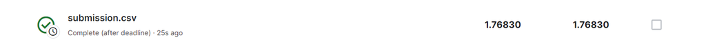

#### Initial score of `1.76830`

## Step 4: Exploratory Data Analysis and Creating an additional feature

- Any additional feature will do, but a great suggestion would be to separate out the datetime into hour, day, or month parts.

```
array([[<Axes: title={'center': 'datetime'}>,
        <Axes: title={'center': 'season'}>,
        <Axes: title={'center': 'holiday'}>],
       [<Axes: title={'center': 'workingday'}>,
        <Axes: title={'center': 'weather'}>,
        <Axes: title={'center': 'temp'}>],
       [<Axes: title={'center': 'atemp'}>,
        <Axes: title={'center': 'humidity'}>,
        <Axes: title={'center': 'windspeed'}>],
       [<Axes: title={'center': 'casual'}>,
        <Axes: title={'center': 'registered'}>,
        <Axes: title={'center': 'count'}>]], dtype=object)
```

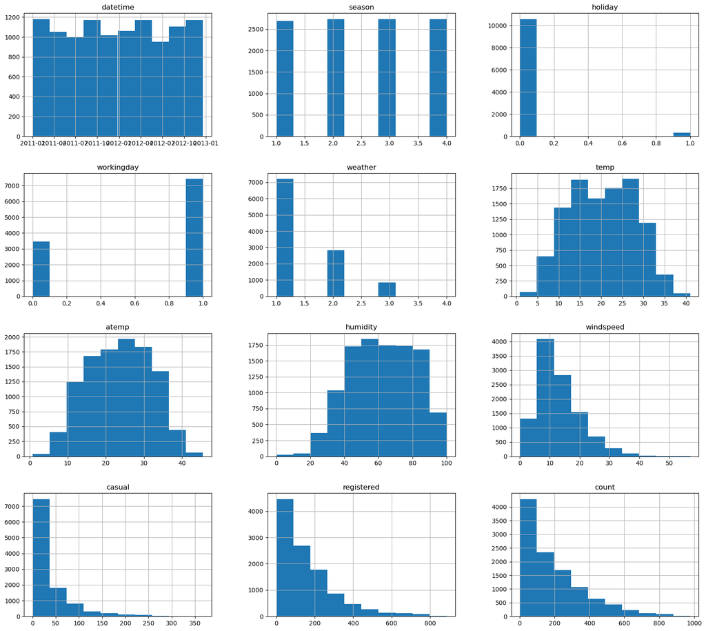

```python
# Create a histogram of all features to show the distribution of each one relative to the data. This is part of the exploritory data analysis
train.hist(figsize=(20, 18))
```

```python
# create a new feature
train['month'] = train['datetime'].dt.month
train['day'] = train['datetime'].dt.day
train['hour'] = train['datetime'].dt.hour

test['month'] = test['datetime'].dt.month
test['day'] = test['datetime'].dt.day
test['hour'] = test['datetime'].dt.hour
```

## Make category types for these so models know they are not just numbers

- AutoGluon originally sees these as ints, but in reality they are int representations of a category.
- Setting the dtype to category will classify these as categories in AutoGluon.

```python
train["season"] = train["season"].astype('category')
train["weather"] = train["weather"].astype('category')
test["season"] = test["season"].astype('category')
test["weather"] = test["weather"].astype('category')
```

```python
# View are new feature
train.head()
```

|  | datetime | season | holiday | workingday | weather | temp | atemp | humidity | windspeed | casual | registered | count | month | day | hour |
| --- | --- | --- | --- | --- | --- | --- | --- | --- | --- | --- | --- | --- | --- | --- | --- |
| 0 | 2011-01-01 00:00:00 | 1 | 0 | 0 | 1 | 9.84 | 14.395 | 81 | 0.0 | 3 | 13 | 16 | 1 | 1 | 0 |
| 1 | 2011-01-01 01:00:00 | 1 | 0 | 0 | 1 | 9.02 | 13.635 | 80 | 0.0 | 8 | 32 | 40 | 1 | 1 | 1 |
| 2 | 2011-01-01 02:00:00 | 1 | 0 | 0 | 1 | 9.02 | 13.635 | 80 | 0.0 | 5 | 27 | 32 | 1 | 1 | 2 |
| 3 | 2011-01-01 03:00:00 | 1 | 0 | 0 | 1 | 9.84 | 14.395 | 75 | 0.0 | 3 | 10 | 13 | 1 | 1 | 3 |
| 4 | 2011-01-01 04:00:00 | 1 | 0 | 0 | 1 | 9.84 | 14.395 | 75 | 0.0 | 0 | 1 | 1 | 1 | 1 | 4 |

```
array([[<Axes: title={'center': 'datetime'}>,
        <Axes: title={'center': 'holiday'}>,
        <Axes: title={'center': 'workingday'}>,
        <Axes: title={'center': 'temp'}>],
       [<Axes: title={'center': 'atemp'}>,
        <Axes: title={'center': 'humidity'}>,
        <Axes: title={'center': 'windspeed'}>,
        <Axes: title={'center': 'casual'}>],
       [<Axes: title={'center': 'registered'}>,
        <Axes: title={'center': 'count'}>,
        <Axes: title={'center': 'month'}>,
        <Axes: title={'center': 'day'}>],
       [<Axes: title={'center': 'hour'}>, <Axes: >, <Axes: >, <Axes: >]],
      dtype=object)
```

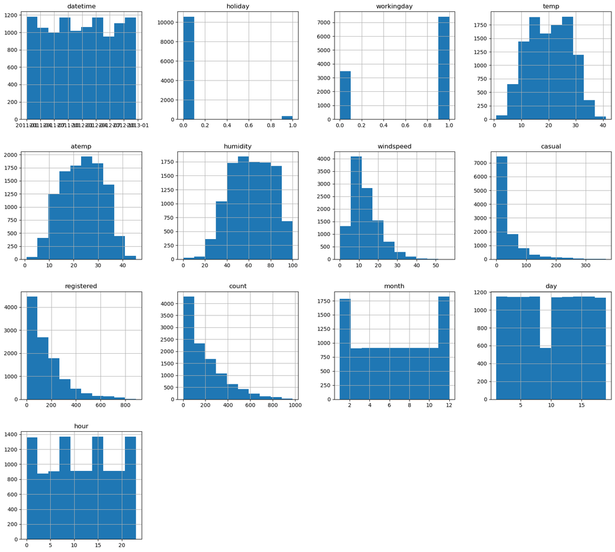

```python
# View histogram of all features again now with the hour feature
train.hist(figsize=(20, 18))
```

## Step 5: Rerun the model with the same settings as before, just with more features

```python
predictor_new_features = TabularPredictor(
    label='count',
    eval_metric='root_mean_squared_error',
    learner_kwargs={
        'ignored_columns': ['casual', 'registered'],
    }
).fit(
    train_data=train,
    time_limit=600,
    presets='best_quality'
)
```

```
No path specified. Models will be saved in: "AutogluonModels/ag-20240504_054015"
Presets specified: ['best_quality']
Stack configuration (auto_stack=True): num_stack_levels=1, num_bag_folds=8, num_bag_sets=20
Beginning AutoGluon training ... Time limit = 600s
AutoGluon will save models to "AutogluonModels/ag-20240504_054015"
AutoGluon Version:  0.8.2
Python Version:     3.10.14
Operating System:   Linux
Platform Machine:   x86_64
Platform Version:   #1 SMP Sat Mar 23 09:49:55 UTC 2024
Disk Space Avail:   19.57 GB / 21.46 GB (91.2%)
Train Data Rows:    10886
Train Data Columns: 14
Label Column: count
Preprocessing data ...
AutoGluon infers your prediction problem is: 'regression' (because dtype of label-column == int and many unique label-values observed).
	Label info (max, min, mean, stddev): (977, 1, 191.57413, 181.14445)
	If 'regression' is not the correct problem_type, please manually specify the problem_type parameter during predictor init (You may specify problem_type as one of: ['binary', 'multiclass', 'regression'])
Using Feature Generators to preprocess the data ...
Dropping user-specified ignored columns: ['casual', 'registered']
Fitting AutoMLPipelineFeatureGenerator...
	Available Memory:                    5609.23 MB
	Train Data (Original)  Memory Usage: 0.76 MB (0.0% of available memory)
	Inferring data type of each feature based on column values. Set feature_metadata_in to manually specify special dtypes of the features.
	Stage 1 Generators:
		Fitting AsTypeFeatureGenerator...
			Note: Converting 2 features to boolean dtype as they only contain 2 unique values.
	Stage 2 Generators:
		Fitting FillNaFeatureGenerator...
	Stage 3 Generators:
		Fitting IdentityFeatureGenerator...
		Fitting CategoryFeatureGenerator...
			Fitting CategoryMemoryMinimizeFeatureGenerator...
		Fitting DatetimeFeatureGenerator...
	Stage 4 Generators:
		Fitting DropUniqueFeatureGenerator...
	Stage 5 Generators:
		Fitting DropDuplicatesFeatureGenerator...
	Types of features in original data (raw dtype, special dtypes):
		('category', []) : 2 | ['season', 'weather']
```

[output cut: 24 more lines]

```
	'XT': [{'criterion': 'gini', 'ag_args': {'name_suffix': 'Gini', 'problem_types': ['binary', 'multiclass']}}, {'criterion': 'entropy', 'ag_args': {'name_suffix': 'Entr', 'problem_types': ['binary', 'multiclass']}}, {'criterion': 'squared_error', 'ag_args': {'name_suffix': 'MSE', 'problem_types': ['r…
	'KNN': [{'weights': 'uniform', 'ag_args': {'name_suffix': 'Unif'}}, {'weights': 'distance', 'ag_args': {'name_suffix': 'Dist'}}],
}
AutoGluon will fit 2 stack levels (L1 to L2) ...
Fitting 11 L1 models ...
Fitting model: KNeighborsUnif_BAG_L1 ... Training model for up to 399.58s of the 599.52s of remaining time.
	-101.5462	 = Validation score   (-root_mean_squared_error)
	0.03s	 = Training   runtime
	0.04s	 = Validation runtime
Fitting model: KNeighborsDist_BAG_L1 ... Training model for up to 399.49s of the 599.43s of remaining time.
	-84.1251	 = Validation score   (-root_mean_squared_error)
	0.03s	 = Training   runtime
	0.04s	 = Validation runtime
Fitting model: LightGBMXT_BAG_L1 ... Training model for up to 399.39s of the 599.33s of remaining time.
	Fitting 8 child models (S1F1 - S1F8) | Fitting with SequentialLocalFoldFittingStrategy
```

[output not shown]

```
	-34.5852	 = Validation score   (-root_mean_squared_error)
	56.28s	 = Training   runtime
	7.66s	 = Validation runtime
Fitting model: LightGBM_BAG_L1 ... Training model for up to 327.09s of the 527.03s of remaining time.
	Fitting 8 child models (S1F1 - S1F8) | Fitting with SequentialLocalFoldFittingStrategy
```

```
[1000]	valid_set's rmse: 33.1718
[2000]	valid_set's rmse: 33.0073
[1000]	valid_set's rmse: 32.8605
[2000]	valid_set's rmse: 32.6379
[1000]	valid_set's rmse: 31.9545
[2000]	valid_set's rmse: 31.3424
[3000]	valid_set's rmse: 30.9034
[4000]	valid_set's rmse: 30.8606
[1000]	valid_set's rmse: 35.8541
[2000]	valid_set's rmse: 35.4833
[3000]	valid_set's rmse: 35.4047
[1000]	valid_set's rmse: 35.5381
[1000]	valid_set's rmse: 31.625
[1000]	valid_set's rmse: 37.9327
[2000]	valid_set's rmse: 37.455
[1000]	valid_set's rmse: 34.943
[2000]	valid_set's rmse: 34.6714
```

```
	-33.9169	 = Validation score   (-root_mean_squared_error)
	20.13s	 = Training   runtime
	2.34s	 = Validation runtime
Fitting model: RandomForestMSE_BAG_L1 ... Training model for up to 301.83s of the 501.77s of remaining time.
	-38.3945	 = Validation score   (-root_mean_squared_error)
	15.23s	 = Training   runtime
	0.55s	 = Validation runtime
Fitting model: CatBoost_BAG_L1 ... Training model for up to 285.64s of the 485.58s of remaining time.
	Fitting 8 child models (S1F1 - S1F8) | Fitting with SequentialLocalFoldFittingStrategy
	Ran out of time, early stopping on iteration 3701.
	Ran out of time, early stopping on iteration 3815.
	Ran out of time, early stopping on iteration 3923.
	Ran out of time, early stopping on iteration 3971.
	Ran out of time, early stopping on iteration 4028.
	Ran out of time, early stopping on iteration 4319.
	Ran out of time, early stopping on iteration 4667.
	Ran out of time, early stopping on iteration 5328.
	-33.6644	 = Validation score   (-root_mean_squared_error)
	273.95s	 = Training   runtime
	0.1s	 = Validation runtime
Fitting model: ExtraTreesMSE_BAG_L1 ... Training model for up to 11.47s of the 211.41s of remaining time.
	-38.4918	 = Validation score   (-root_mean_squared_error)
	6.88s	 = Training   runtime
	0.53s	 = Validation runtime
Fitting model: NeuralNetFastAI_BAG_L1 ... Training model for up to 3.63s of the 203.57s of remaining time.
	Fitting 8 child models (S1F1 - S1F8) | Fitting with SequentialLocalFoldFittingStrategy
	Ran out of time, stopping training early. (Stopping on epoch 0)
	Time limit exceeded... Skipping NeuralNetFastAI_BAG_L1.
Fitting model: XGBoost_BAG_L1 ... Training model for up to 3.04s of the 202.98s of remaining time.
	Fitting 8 child models (S1F1 - S1F8) | Fitting with SequentialLocalFoldFittingStrategy
	-36.8982	 = Validation score   (-root_mean_squared_error)
	2.8s	 = Training   runtime
	0.14s	 = Validation runtime
Fitting model: NeuralNetTorch_BAG_L1 ... Training model for up to 0.05s of the 199.99s of remaining time.
	Fitting 8 child models (S1F1 - S1F8) | Fitting with SequentialLocalFoldFittingStrategy
	Time limit exceeded... Skipping NeuralNetTorch_BAG_L1.
Completed 1/20 k-fold bagging repeats ...
Fitting model: WeightedEnsemble_L2 ... Training model for up to 360.0s of the 199.91s of remaining time.
	-32.1431	 = Validation score   (-root_mean_squared_error)
	0.31s	 = Training   runtime
	0.0s	 = Validation runtime
Fitting 9 L2 models ...
Fitting model: LightGBMXT_BAG_L2 ... Training model for up to 199.59s of the 199.58s of remaining time.
	Fitting 8 child models (S1F1 - S1F8) | Fitting with SequentialLocalFoldFittingStrategy
```

```
[1000]	valid_set's rmse: 34.3521
[1000]	valid_set's rmse: 28.9482
[1000]	valid_set's rmse: 30.0693
[1000]	valid_set's rmse: 30.7059
```

```
	-31.0342	 = Validation score   (-root_mean_squared_error)
	12.97s	 = Training   runtime
	0.78s	 = Validation runtime
Fitting model: LightGBM_BAG_L2 ... Training model for up to 184.81s of the 184.8s of remaining time.
	Fitting 8 child models (S1F1 - S1F8) | Fitting with SequentialLocalFoldFittingStrategy
	-30.7761	 = Validation score   (-root_mean_squared_error)
	9.67s	 = Training   runtime
	0.27s	 = Validation runtime
Fitting model: RandomForestMSE_BAG_L2 ... Training model for up to 174.42s of the 174.41s of remaining time.
	-31.7365	 = Validation score   (-root_mean_squared_error)
	40.79s	 = Training   runtime
	0.6s	 = Validation runtime
Fitting model: CatBoost_BAG_L2 ... Training model for up to 132.62s of the 132.61s of remaining time.
	Fitting 8 child models (S1F1 - S1F8) | Fitting with SequentialLocalFoldFittingStrategy
	Ran out of time, early stopping on iteration 1587.
	Ran out of time, early stopping on iteration 1729.
	-30.5601	 = Validation score   (-root_mean_squared_error)
	124.26s	 = Training   runtime
	0.05s	 = Validation runtime
Fitting model: ExtraTreesMSE_BAG_L2 ... Training model for up to 8.25s of the 8.24s of remaining time.
	-31.637	 = Validation score   (-root_mean_squared_error)
	11.17s	 = Training   runtime
	0.59s	 = Validation runtime
Completed 1/20 k-fold bagging repeats ...
Fitting model: WeightedEnsemble_L3 ... Training model for up to 360.0s of the -3.98s of remaining time.
	-30.2737	 = Validation score   (-root_mean_squared_error)
	0.23s	 = Training   runtime
	0.0s	 = Validation runtime
AutoGluon training complete, total runtime = 604.23s ... Best model: "WeightedEnsemble_L3"
TabularPredictor saved. To load, use: predictor = TabularPredictor.load("AutogluonModels/ag-20240504_054015")
```

```python
predictor_new_features.fit_summary()
```

```
*** Summary of fit() ***
Estimated performance of each model:
                     model   score_val  pred_time_val    fit_time  pred_time_val_marginal  fit_time_marginal  stack_level  can_infer  fit_order
0      WeightedEnsemble_L3  -30.273676      13.121077  563.239861                0.000523           0.228338            3       True         15
1          CatBoost_BAG_L2  -30.560076      11.459022  499.579496                0.051625         124.257777            2       True         13
2          LightGBM_BAG_L2  -30.776056      11.681070  384.993329                0.273673           9.671609            2       True         11
3        LightGBMXT_BAG_L2  -31.034179      12.190464  388.287482                0.783067          12.965763            2       True         10
4     ExtraTreesMSE_BAG_L2  -31.636953      11.995424  386.495918                0.588027          11.174199            2       True         14
5   RandomForestMSE_BAG_L2  -31.736533      12.012189  416.116373                0.604792          40.794653            2       True         12
6      WeightedEnsemble_L2  -32.143072      10.695106  365.918627                0.000512           0.308993            2       True          9
7          CatBoost_BAG_L1  -33.664377       0.102143  273.945493                0.102143         273.945493            1       True          6
8          LightGBM_BAG_L1  -33.916921       2.339348   20.128467                2.339348          20.128467            1       True          4
9        LightGBMXT_BAG_L1  -34.585182       7.658481   56.277282                7.658481          56.277282            1       True          3
10          XGBoost_BAG_L1  -36.898221       0.135446    2.800887                0.135446           2.800887            1       True          8
11  RandomForestMSE_BAG_L1  -38.394461       0.550537   15.232072                0.550537          15.232072            1       True          5
12    ExtraTreesMSE_BAG_L1  -38.491830       0.533738    6.884239                0.533738           6.884239            1       True          7
13   KNeighborsDist_BAG_L1  -84.125061       0.044084    0.026319                0.044084           0.026319            1       True          2
14   KNeighborsUnif_BAG_L1 -101.546199       0.043619    0.026960                0.043619           0.026960            1       True          1
Number of models trained: 15
Types of models trained:
{'StackerEnsembleModel_CatBoost', 'WeightedEnsembleModel', 'StackerEnsembleModel_XGBoost', 'StackerEnsembleModel_LGB', 'StackerEnsembleModel_KNN', 'StackerEnsembleModel_RF', 'StackerEnsembleModel_XT'}
Bagging used: True  (with 8 folds)
Multi-layer stack-ensembling used: True  (with 3 levels)
Feature Metadata (Processed):
(raw dtype, special dtypes):
('category', [])             : 2 | ['season', 'weather']
('float', [])                : 3 | ['temp', 'atemp', 'windspeed']
('int', [])                  : 4 | ['humidity', 'month', 'day', 'hour']
('int', ['bool'])            : 2 | ['holiday', 'workingday']
('int', ['datetime_as_int']) : 3 | ['datetime', 'datetime.year', 'datetime.dayofweek']
*** End of fit() summary ***
```

[output not shown]

[output cut: 139 more lines]

[output not shown]

```python
# Create predictions from test dataset
predictions_new_features = predictor_new_features.predict(test)
predictions_new_features.head()
```

```
0    15.942666
1    10.588608
2     9.580529
3     8.439346
4     7.317397
Name: count, dtype: float32
```

```python
# Remember to set all negative values to zero
predictions_new_features[predictions_new_features < 0] = 0
```

```python
submission_new_features = pd.DataFrame(pd.read_csv("sampleSubmission.csv"))
submission_new_features['datetime'] = pd.to_datetime(submission_new_features['datetime'])
submission_new_features.head()
```

|  | datetime | count |
| --- | --- | --- |
| 0 | 2011-01-20 00:00:00 | 0 |
| 1 | 2011-01-20 01:00:00 | 0 |
| 2 | 2011-01-20 02:00:00 | 0 |
| 3 | 2011-01-20 03:00:00 | 0 |
| 4 | 2011-01-20 04:00:00 | 0 |

```python
# Same submitting predictions
submission_new_features["count"] = predictions_new_features
submission_new_features.to_csv("submission_new_features.csv", index=False)
```

```python
!kaggle competitions submit -c bike-sharing-demand -f submission_new_features.csv -m "new features"
```

```python
!kaggle competitions submissions -c bike-sharing-demand | tail -n +1 | head -n 6
```

# Submission Score

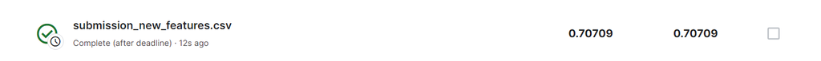

#### New Score of `0.70709`

## Step 6: Hyper parameter optimization

- There are many options for hyper parameter optimization.
- Options are to change the AutoGluon higher level parameters or the individual model hyperparameters.
- The hyperparameters of the models themselves that are in AutoGluon. Those need the `hyperparameter` and `hyperparameter_tune_kwargs` arguments.

```python
predictor_new_hpo = TabularPredictor(
    label='count',
    eval_metric='root_mean_squared_error',
    learner_kwargs={
        'ignored_columns': ['casual', 'registered'],
    }
).fit(
    train_data=train,
    time_limit=600,
    presets='best_quality',
    hyperparameters='light',
    hyperparameter_tune_kwargs='auto',
)
```

```
No path specified. Models will be saved in: "AutogluonModels/ag-20240504_055116"
Presets specified: ['best_quality']
Warning: hyperparameter tuning is currently experimental and may cause the process to hang.
Stack configuration (auto_stack=True): num_stack_levels=1, num_bag_folds=8, num_bag_sets=20
Beginning AutoGluon training ... Time limit = 600s
AutoGluon will save models to "AutogluonModels/ag-20240504_055116"
AutoGluon Version:  0.8.2
Python Version:     3.10.14
Operating System:   Linux
Platform Machine:   x86_64
Platform Version:   #1 SMP Sat Mar 23 09:49:55 UTC 2024
Disk Space Avail:   18.20 GB / 21.46 GB (84.8%)
Train Data Rows:    10886
Train Data Columns: 14
Label Column: count
Preprocessing data ...
AutoGluon infers your prediction problem is: 'regression' (because dtype of label-column == int and many unique label-values observed).
	Label info (max, min, mean, stddev): (977, 1, 191.57413, 181.14445)
	If 'regression' is not the correct problem_type, please manually specify the problem_type parameter during predictor init (You may specify problem_type as one of: ['binary', 'multiclass', 'regression'])
Using Feature Generators to preprocess the data ...
Dropping user-specified ignored columns: ['casual', 'registered']
Fitting AutoMLPipelineFeatureGenerator...
	Available Memory:                    5617.5 MB
	Train Data (Original)  Memory Usage: 0.76 MB (0.0% of available memory)
	Inferring data type of each feature based on column values. Set feature_metadata_in to manually specify special dtypes of the features.
	Stage 1 Generators:
		Fitting AsTypeFeatureGenerator...
			Note: Converting 2 features to boolean dtype as they only contain 2 unique values.
	Stage 2 Generators:
		Fitting FillNaFeatureGenerator...
	Stage 3 Generators:
		Fitting IdentityFeatureGenerator...
		Fitting CategoryFeatureGenerator...
			Fitting CategoryMemoryMinimizeFeatureGenerator...
		Fitting DatetimeFeatureGenerator...
	Stage 4 Generators:
		Fitting DropUniqueFeatureGenerator...
	Stage 5 Generators:
		Fitting DropDuplicatesFeatureGenerator...
	Types of features in original data (raw dtype, special dtypes):
```

[output cut: 16 more lines]

```
	To change this, specify the eval_metric parameter of Predictor()
User-specified model hyperparameters to be fit:
{
	'NN_TORCH': {},
	'GBM': [{'extra_trees': True, 'ag_args': {'name_suffix': 'XT'}}, {}, 'GBMLarge'],
	'CAT': {},
	'XGB': {},
	'FASTAI': {},
	'RF': [{'criterion': 'gini', 'max_depth': 15, 'ag_args': {'name_suffix': 'Gini', 'problem_types': ['binary', 'multiclass']}}, {'criterion': 'entropy', 'max_depth': 15, 'ag_args': {'name_suffix': 'Entr', 'problem_types': ['binary', 'multiclass']}}, {'criterion': 'squared_error', 'max_depth': 15, 'ag…
	'XT': [{'criterion': 'gini', 'max_depth': 15, 'ag_args': {'name_suffix': 'Gini', 'problem_types': ['binary', 'multiclass']}}, {'criterion': 'entropy', 'max_depth': 15, 'ag_args': {'name_suffix': 'Entr', 'problem_types': ['binary', 'multiclass']}}, {'criterion': 'squared_error', 'max_depth': 15, 'ag…
}
AutoGluon will fit 2 stack levels (L1 to L2) ...
Fitting 9 L1 models ...
Hyperparameter tuning model: LightGBMXT_BAG_L1 ... Tuning model for up to 39.96s of the 599.54s of remaining time.
	Fitting 8 child models (S1F1 - S1F8) | Fitting with SequentialLocalFoldFittingStrategy
```

```
[1000]	valid_set's rmse: 36.7837
[2000]	valid_set's rmse: 34.6762
[3000]	valid_set's rmse: 34.2731
[4000]	valid_set's rmse: 34.1852
```

```
	Ran out of time, early stopping on iteration 4463. Best iteration is:
	[4306]	valid_set's rmse: 34.1569
	Fitting 8 child models (S1F1 - S1F8) | Fitting with SequentialLocalFoldFittingStrategy
```

```
[1000]	valid_set's rmse: 37.802
[2000]	valid_set's rmse: 36.7969
```

```
	Ran out of time, early stopping on iteration 2413. Best iteration is:
	[2338]	valid_set's rmse: 36.6888
	Fitting 8 child models (S1F1 - S1F8) | Fitting with SequentialLocalFoldFittingStrategy
```

```
[1000]	valid_set's rmse: 37.1853
```

```
	Ran out of time, early stopping on iteration 2162. Best iteration is:
	[2161]	valid_set's rmse: 34.6837
```

```
[2000]	valid_set's rmse: 34.8463
```

```
	Fitting 8 child models (S1F1 - S1F8) | Fitting with SequentialLocalFoldFittingStrategy
```

```
[1000]	valid_set's rmse: 72.4153
```

```
	Ran out of time, early stopping on iteration 1662. Best iteration is:
	[1662]	valid_set's rmse: 59.2901
	Fitting 8 child models (S1F1 - S1F8) | Fitting with SequentialLocalFoldFittingStrategy
```

```
[1000]	valid_set's rmse: 35.4242
```

```
	Ran out of time, early stopping on iteration 1593. Best iteration is:
	[1536]	valid_set's rmse: 34.8829
	Fitting 8 child models (S1F1 - S1F8) | Fitting with SequentialLocalFoldFittingStrategy
	Ran out of time, early stopping on iteration 1061. Best iteration is:
	[1061]	valid_set's rmse: 46.0543
```

```
[1000]	valid_set's rmse: 46.8472
```

```
	Fitting 8 child models (S1F1 - S1F8) | Fitting with SequentialLocalFoldFittingStrategy
	Ran out of time, early stopping on iteration 984. Best iteration is:
	[983]	valid_set's rmse: 35.9389
	Fitting 8 child models (S1F1 - S1F8) | Fitting with SequentialLocalFoldFittingStrategy
	Ran out of time, early stopping on iteration 1015. Best iteration is:
	[1014]	valid_set's rmse: 34.8809
```

```
[1000]	valid_set's rmse: 34.9012
```

[output not shown]

```
[1000]	valid_set's rmse: 33.1718
[2000]	valid_set's rmse: 33.0073
[1000]	valid_set's rmse: 32.8605
[2000]	valid_set's rmse: 32.6379
[1000]	valid_set's rmse: 31.9545
[2000]	valid_set's rmse: 31.3424
[3000]	valid_set's rmse: 30.9034
[4000]	valid_set's rmse: 30.8606
[1000]	valid_set's rmse: 35.8541
[2000]	valid_set's rmse: 35.4833
[3000]	valid_set's rmse: 35.4047
[1000]	valid_set's rmse: 35.5381
[1000]	valid_set's rmse: 31.625
[1000]	valid_set's rmse: 37.9327
[2000]	valid_set's rmse: 37.455
[1000]	valid_set's rmse: 34.943
[2000]	valid_set's rmse: 34.6714
```

```
	Stopping HPO to satisfy time limit...
Fitted model: LightGBM_BAG_L1/T1 ...
	-33.9169	 = Validation score   (-root_mean_squared_error)
	24.48s	 = Training   runtime
	0.0s	 = Validation runtime
Hyperparameter tuning model: RandomForestMSE_BAG_L1 ... Tuning model for up to 39.96s of the 535.12s of remaining time.
	No hyperparameter search space specified for RandomForestMSE_BAG_L1. Skipping HPO. Will train one model based on the provided hyperparameters.
Fitted model: RandomForestMSE_BAG_L1 ...
	-38.7895	 = Validation score   (-root_mean_squared_error)
	12.88s	 = Training   runtime
	0.0s	 = Validation runtime
Hyperparameter tuning model: CatBoost_BAG_L1 ... Tuning model for up to 39.96s of the 522.22s of remaining time.
	Fitting 8 child models (S1F1 - S1F8) | Fitting with SequentialLocalFoldFittingStrategy
	Ran out of time, early stopping on iteration 589.
	Ran out of time, early stopping on iteration 614.
	Ran out of time, early stopping on iteration 638.
	Ran out of time, early stopping on iteration 654.
	Ran out of time, early stopping on iteration 668.
	Ran out of time, early stopping on iteration 726.
	Ran out of time, early stopping on iteration 794.
	Ran out of time, early stopping on iteration 931.
	Stopping HPO to satisfy time limit...
Fitted model: CatBoost_BAG_L1/T1 ...
	-38.0564	 = Validation score   (-root_mean_squared_error)
	34.52s	 = Training   runtime
	0.0s	 = Validation runtime
Hyperparameter tuning model: ExtraTreesMSE_BAG_L1 ... Tuning model for up to 39.96s of the 487.67s of remaining time.
	No hyperparameter search space specified for ExtraTreesMSE_BAG_L1. Skipping HPO. Will train one model based on the provided hyperparameters.
Fitted model: ExtraTreesMSE_BAG_L1 ...
	-39.355	 = Validation score   (-root_mean_squared_error)
	6.14s	 = Training   runtime
	0.0s	 = Validation runtime
Hyperparameter tuning model: NeuralNetFastAI_BAG_L1 ... Tuning model for up to 39.96s of the 481.52s of remaining time.
Will use custom hpo logic because ray import failed. Reason: ray is required to train folds in parallel for TabularPredictor or HPO for MultiModalPredictor. A quick tip is to install via `pip install ray==2.6.3`
	Fitting 8 child models (S1F1 - S1F8) | Fitting with SequentialLocalFoldFittingStrategy
	Ran out of time, stopping training early. (Stopping on epoch 10)
	Ran out of time, stopping training early. (Stopping on epoch 10)
	Ran out of time, stopping training early. (Stopping on epoch 11)
	Ran out of time, stopping training early. (Stopping on epoch 12)
	Ran out of time, stopping training early. (Stopping on epoch 13)
```

[output cut: 16 more lines]

```
	Fitting 8 child models (S1F1 - S1F8) | Fitting with SequentialLocalFoldFittingStrategy
	Ran out of time, stopping training early. (Stopping on epoch 14)
	Ran out of time, stopping training early. (Stopping on epoch 14)
	Ran out of time, stopping training early. (Stopping on epoch 14)
	Ran out of time, stopping training early. (Stopping on epoch 15)
	Ran out of time, stopping training early. (Stopping on epoch 17)
	Ran out of time, stopping training early. (Stopping on epoch 19)
	Ran out of time, stopping training early. (Stopping on epoch 23)
	Stopping HPO to satisfy time limit...
Fitted model: NeuralNetTorch_BAG_L1/T1 ...
	-100.0584	 = Validation score   (-root_mean_squared_error)
	34.24s	 = Training   runtime
	0.0s	 = Validation runtime
Fitting model: LightGBMLarge_BAG_L1 ... Training model for up to 39.96s of the 390.61s of remaining time.
	Fitting 8 child models (S1F1 - S1F8) | Fitting with SequentialLocalFoldFittingStrategy
```

```
[1000]	valid_set's rmse: 33.3046
[1000]	valid_set's rmse: 33.2591
[2000]	valid_set's rmse: 33.2006
[1000]	valid_set's rmse: 32.2988
[1000]	valid_set's rmse: 34.2283
[1000]	valid_set's rmse: 30.4699
[1000]	valid_set's rmse: 36.7116
[1000]	valid_set's rmse: 32.8506
```

```
	-33.6101	 = Validation score   (-root_mean_squared_error)
	24.03s	 = Training   runtime
	1.76s	 = Validation runtime
Completed 1/20 k-fold bagging repeats ...
Fitting model: WeightedEnsemble_L2 ... Training model for up to 360.0s of the 359.61s of remaining time.
	-32.5637	 = Validation score   (-root_mean_squared_error)
	0.34s	 = Training   runtime
	0.0s	 = Validation runtime
Fitting 9 L2 models ...
Hyperparameter tuning model: LightGBMXT_BAG_L2 ... Tuning model for up to 35.93s of the 359.25s of remaining time.
	Fitting 8 child models (S1F1 - S1F8) | Fitting with SequentialLocalFoldFittingStrategy
	Fitting 8 child models (S1F1 - S1F8) | Fitting with SequentialLocalFoldFittingStrategy
	Fitting 8 child models (S1F1 - S1F8) | Fitting with SequentialLocalFoldFittingStrategy
	Stopping HPO to satisfy time limit...
Fitted model: LightGBMXT_BAG_L2/T1 ...
	-33.4903	 = Validation score   (-root_mean_squared_error)
	8.34s	 = Training   runtime
	0.0s	 = Validation runtime
Fitted model: LightGBMXT_BAG_L2/T2 ...
	-34.1382	 = Validation score   (-root_mean_squared_error)
	9.26s	 = Training   runtime
	0.0s	 = Validation runtime
Fitted model: LightGBMXT_BAG_L2/T3 ...
	-33.5373	 = Validation score   (-root_mean_squared_error)
	11.86s	 = Training   runtime
	0.0s	 = Validation runtime
Hyperparameter tuning model: LightGBM_BAG_L2 ... Tuning model for up to 35.93s of the 329.74s of remaining time.
	Fitting 8 child models (S1F1 - S1F8) | Fitting with SequentialLocalFoldFittingStrategy
	Fitting 8 child models (S1F1 - S1F8) | Fitting with SequentialLocalFoldFittingStrategy
	Fitting 8 child models (S1F1 - S1F8) | Fitting with SequentialLocalFoldFittingStrategy
	Stopping HPO to satisfy time limit...
Fitted model: LightGBM_BAG_L2/T1 ...
	-33.1175	 = Validation score   (-root_mean_squared_error)
	7.11s	 = Training   runtime
	0.0s	 = Validation runtime
Fitted model: LightGBM_BAG_L2/T2 ...
	-33.3002	 = Validation score   (-root_mean_squared_error)
	10.04s	 = Training   runtime
	0.0s	 = Validation runtime
Fitted model: LightGBM_BAG_L2/T3 ...
```

[output cut: 72 more lines]

```
	-33.8463	 = Validation score   (-root_mean_squared_error)
	30.89s	 = Training   runtime
	0.0s	 = Validation runtime
Fitting model: LightGBMLarge_BAG_L2 ... Training model for up to 35.93s of the 132.97s of remaining time.
	Fitting 8 child models (S1F1 - S1F8) | Fitting with SequentialLocalFoldFittingStrategy
	-33.4798	 = Validation score   (-root_mean_squared_error)
	17.01s	 = Training   runtime
	0.17s	 = Validation runtime
Completed 1/20 k-fold bagging repeats ...
Fitting model: WeightedEnsemble_L3 ... Training model for up to 360.0s of the 115.03s of remaining time.
	-32.5217	 = Validation score   (-root_mean_squared_error)
	0.46s	 = Training   runtime
	0.0s	 = Validation runtime
AutoGluon training complete, total runtime = 485.46s ... Best model: "WeightedEnsemble_L3"
TabularPredictor saved. To load, use: predictor = TabularPredictor.load("AutogluonModels/ag-20240504_055116")
```

```python
predictor_new_hpo.fit_summary()
```

```
*** Summary of fit() ***
Estimated performance of each model:
                        model   score_val  pred_time_val    fit_time  pred_time_val_marginal  fit_time_marginal  stack_level  can_infer  fit_order
0         WeightedEnsemble_L3  -32.521691       1.759257  346.069520                0.000589           0.462156            3       True         26
1         WeightedEnsemble_L2  -32.563731       1.758056  124.706720                0.000523           0.341098            2       True         10
2        ExtraTreesMSE_BAG_L2  -32.675771       1.757961  206.154073                0.000144           8.065086            2       True         19
3          LightGBM_BAG_L2/T1  -33.117535       1.757901  205.196311                0.000083           7.107324            2       True         14
4          CatBoost_BAG_L2/T1  -33.123661       1.757911  229.115174                0.000093          31.026187            2       True         18
5          LightGBM_BAG_L2/T3  -33.152658       1.757909  208.402301                0.000091          10.313314            2       True         16
6           XGBoost_BAG_L2/T2  -33.268042       1.757899  207.968576                0.000082           9.879589            2       True         22
7          LightGBM_BAG_L2/T2  -33.300176       1.757917  208.124421                0.000099          10.035434            2       True         15
8      RandomForestMSE_BAG_L2  -33.420745       1.757966  234.223231                0.000149          36.134244            2       True         17
9        LightGBMLarge_BAG_L2  -33.479817       1.922820  215.096412                0.165002          17.007425            2       True         25
10          XGBoost_BAG_L2/T1  -33.480577       1.757894  208.871647                0.000076          10.782660            2       True         21
11       LightGBMXT_BAG_L2/T1  -33.490283       1.757931  206.424191                0.000113           8.335205            2       True         11
12       LightGBMXT_BAG_L2/T3  -33.537278       1.757952  209.949266                0.000134          11.860279            2       True         13
13          XGBoost_BAG_L2/T3  -33.593646       1.757893  209.369024                0.000075          11.280037            2       True         23
14       LightGBMLarge_BAG_L1  -33.610136       1.756926   24.034678                1.756926          24.034678            1       True          9
15   NeuralNetTorch_BAG_L2/T1  -33.846303       1.757898  228.980778                0.000080          30.891791            2       True         24
16         LightGBM_BAG_L1/T1  -33.916921       0.000146   24.480048                0.000146          24.480048            1       True          2
17  NeuralNetFastAI_BAG_L2/T1  -34.130706       1.757888  229.050364                0.000070          30.961377            2       True         20
18       LightGBMXT_BAG_L2/T2  -34.138222       1.757915  207.348747                0.000098           9.259760            2       True         12
19          XGBoost_BAG_L1/T1  -34.580649       0.000100   22.317146                0.000100          22.317146            1       True          7
20         CatBoost_BAG_L1/T1  -38.056369       0.000076   34.515501                0.000076          34.515501            1       True          4
21     RandomForestMSE_BAG_L1  -38.789487       0.000138   12.881298                0.000138          12.881298            1       True          3
22       ExtraTreesMSE_BAG_L1  -39.355036       0.000147    6.136951                0.000147           6.136951            1       True          5
23      LightGBMXT_BAG_L1/T14  -56.284924       0.000128    5.207680                0.000128           5.207680            1       True          1
24  NeuralNetFastAI_BAG_L1/T1  -64.155316       0.000080   34.278292                0.000080          34.278292            1       True          6
25   NeuralNetTorch_BAG_L1/T1 -100.058414       0.000077   34.237392                0.000077          34.237392            1       True          8
Number of models trained: 26
Types of models trained:
{'StackerEnsembleModel_CatBoost', 'StackerEnsembleModel_NNFastAiTabular', 'WeightedEnsembleModel', 'StackerEnsembleModel_XGBoost', 'StackerEnsembleModel_TabularNeuralNetTorch', 'StackerEnsembleModel_LGB', 'StackerEnsembleModel_RF', 'StackerEnsembleModel_XT'}
Bagging used: True  (with 8 folds)
Multi-layer stack-ensembling used: True  (with 3 levels)
Feature Metadata (Processed):
(raw dtype, special dtypes):
('category', [])             : 2 | ['season', 'weather']
('float', [])                : 3 | ['temp', 'atemp', 'windspeed']
('int', [])                  : 4 | ['humidity', 'month', 'day', 'hour']
('int', ['bool'])            : 2 | ['holiday', 'workingday']
('int', ['datetime_as_int']) : 3 | ['datetime', 'datetime.year', 'datetime.dayofweek']
*** End of fit() summary ***
```

[output not shown]

[output cut: 269 more lines]

[output not shown]

```python
# Create predictions from test dataset
predictions_new_hpo = predictor_new_hpo.predict(test)
predictions_new_hpo.head()
```

```
0    13.502995
1     4.529788
2     4.028780
3     3.194845
4     3.269758
Name: count, dtype: float32
```

```python
# Remember to set all negative values to zero
predictions_new_hpo[predictions_new_hpo < 0] = 0
```

```python
submission_new_hpo = pd.DataFrame(pd.read_csv("sampleSubmission.csv"))
submission_new_hpo['datetime'] = pd.to_datetime(submission_new_hpo['datetime'])
submission_new_hpo.head()
```

|  | datetime | count |
| --- | --- | --- |
| 0 | 2011-01-20 00:00:00 | 0 |
| 1 | 2011-01-20 01:00:00 | 0 |
| 2 | 2011-01-20 02:00:00 | 0 |
| 3 | 2011-01-20 03:00:00 | 0 |
| 4 | 2011-01-20 04:00:00 | 0 |

```python
# Same submitting predictions
submission_new_hpo["count"] = predictions_new_hpo
submission_new_hpo.to_csv("submission_new_hpo.csv", index=False)
```

```python
!kaggle competitions submit -c bike-sharing-demand -f submission_new_hpo.csv -m "new features with hyperparameters"
```

```python
!kaggle competitions submissions -c bike-sharing-demand | tail -n +1 | head -n 6
```

# Submission Score

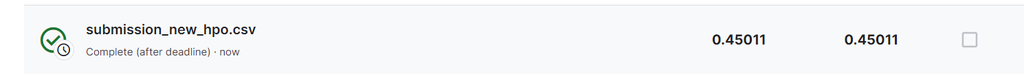

#### New Score of `0.45011`

## Step 7: Write a Report

### Refer to the markdown file for the full report

### Creating plots and table for report

```
                     model   score_val  pred_time_val    fit_time  pred_time_val_marginal  fit_time_marginal  stack_level  can_infer  fit_order
0      WeightedEnsemble_L3  -52.139211       8.953876  462.226066                0.000532           0.263857            3       True         19
1   RandomForestMSE_BAG_L2  -53.410760       8.204880  423.298584                0.581016          42.521671            2       True         14
2     ExtraTreesMSE_BAG_L2  -53.943016       8.213194  392.299085                0.589331          11.522171            2       True         16
3   NeuralNetFastAI_BAG_L2  -54.557075       7.782997  407.918367                0.159133          27.141453            2       True         17
4          LightGBM_BAG_L2  -55.258763       7.778074  389.314777                0.154211           8.537863            2       True         13
5          CatBoost_BAG_L2  -55.556197       7.661150  446.833604                0.037286          66.056691            2       True         15
6        LightGBMXT_BAG_L2  -60.437201      10.260730  415.850474                2.636866          35.073560            2       True         12
7           XGBoost_BAG_L2  -62.488061       7.667592  382.196335                0.043729           1.419421            2       True         18
8    KNeighborsDist_BAG_L1  -84.125061       0.043686    0.029064                0.043686           0.029064            1       True          2
9      WeightedEnsemble_L2  -84.125061       0.044213    0.395354                0.000526           0.366290            2       True         11
10   KNeighborsUnif_BAG_L1 -101.546199       0.043876    0.033044                0.043876           0.033044            1       True          1
11  RandomForestMSE_BAG_L1 -116.548359       0.531135   13.458154                0.531135          13.458154            1       True          5
12    ExtraTreesMSE_BAG_L1 -124.600676       0.506811    6.960288                0.506811           6.960288            1       True          7
13         CatBoost_BAG_L1 -130.466966       0.068925  212.513005                0.068925         212.513005            1       True          6
```

[output cut: 48 more lines]

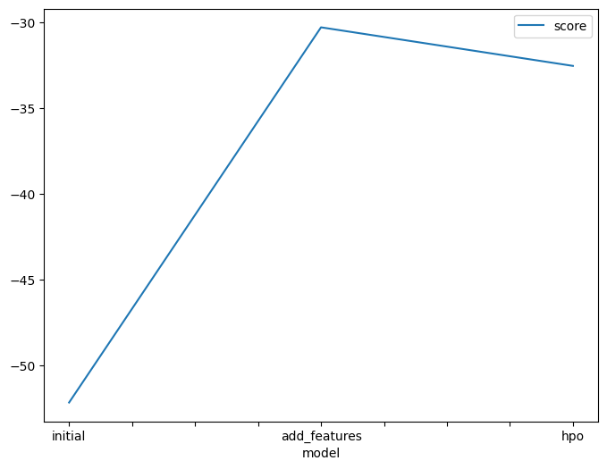

```python
# Taking the top model score from each training run and creating a line plot to show improvement
# You can create these in the notebook and save them to PNG or use some other tool (e.g. google sheets, excel)
initial_score = predictor.leaderboard()['score_val'][0]
new_features_score = predictor_new_features.leaderboard()['score_val'][0]
new_hpo_score = predictor_new_hpo.leaderboard()['score_val'][0]

fig = pd.DataFrame(
    {
        "model": ["initial", "add_features", "hpo"],
        "score": [initial_score, new_features_score, new_hpo_score]
    }
).plot(x="model", y="score", figsize=(8, 6)).get_figure()
fig.savefig('model_train_score.png')
```

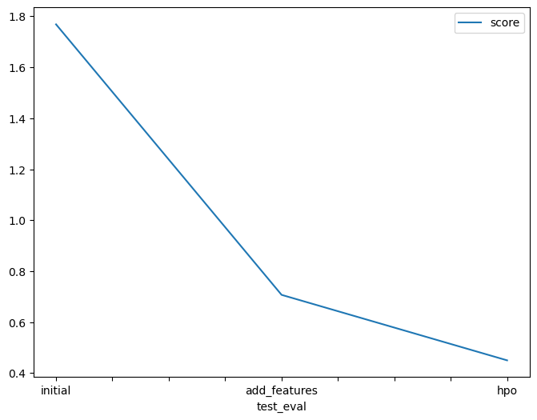

```python
# Take the 3 kaggle scores and creating a line plot to show improvement
fig = pd.DataFrame(
    {
        "test_eval": ["initial", "add_features", "hpo"],
        "score": [1.76830, 0.70709, 0.45011]
    }
).plot(x="test_eval", y="score", figsize=(8, 6)).get_figure()
fig.savefig('model_test_score.png')
```

### Hyperparameter table

```python
# The 3 hyperparameters we tuned with the kaggle score as the result
pd.DataFrame({
    "model": ["initial", "add_features", "hpo"],
    "hpo1": ['time_limit=600', 'time_limit=600', 'time_limit=600'],
    "hpo2": ['presets=best_quality', 'presets=best_quality', 'presets=best_quality'],
    "hpo3": ['hyperparameter=default', 'hyperparameter=default', 'hyperparameter=light'],
    "score": [1.76830, 0.70709, 0.45011]
})
```

|  | model | hpo1 | hpo2 | hpo3 | score |
| --- | --- | --- | --- | --- | --- |
| 0 | initial | time_limit=600 | presets=best_quality | hyperparameter=default | 1.76830 |
| 1 | add_features | time_limit=600 | presets=best_quality | hyperparameter=default | 0.70709 |
| 2 | hpo | time_limit=600 | presets=best_quality | hyperparameter=light | 0.45011 |